# Example on simulating uncertainties using Monte Carlo simulation

Adrian Chong

2024-02-22

## Background

Example of simulating uncertainties in two variables independently using Monte Carlo simulation. This example uses the DOE medium office commercial prototype building models for climate zone 3C in which the representative city is San Diego, California, USA. The two variables in this example are the `Lighting Power Density (LPD)` and the `Electric Equipment Power Density (EPD)`.

Packages used in this example

```r
library(here)
library(eplusr)
library(triangulr)
library(knitr)
library(tidyverse)
```

## Parsing EnergyPlus into R

Set path of the DOE medium office prototype model (`idf_path`) and the weather file (`epw_path`) that will be used in this example, which is the TMY3 for San Diego, CA.

```r
idf_path <- here("data", "monte_carlo", "ASHRAE901_OfficeMedium_STD2022_SanDiego.idf")
epw_path <- here("data", "monte_carlo", "USA_CA_San.Deigo-Brown.Field_.Muni_.AP_.722904_TMY3.epw")
```

Parse the model and the TMY3 weather file into R using the `read_idf` and `read_epw` function from the `eplusr` package.

```r
idf_model <- read_idf(idf_path)
```

```
## IDD v22.1.0 has not been parsed before.
## Try to locate 'Energy+.idd' in EnergyPlus v22.1.0 installation folder '/Applications/EnergyPlus-22-1-0'.
```

```
## IDD file found: '/Applications/EnergyPlus-22-1-0/Energy+.idd'.
```

```
## Start parsing...
```

```
## Parsing completed.
```

```r
epw <- read_epw(epw_path)
```

Run the simulation to obtain the electricity energy use of the base model

```r
job <- idf_model$run(weather = epw, dir = tempdir())
```

[output not shown]

```r
base_report <- job$tabular_data() %>%
    filter(report_name == "AnnualBuildingUtilityPerformanceSummary",
           table_name == "End Uses",
           column_name == "Electricity",
           row_name == "Total End Uses") %>%
    mutate(case = map_chr(str_split(case, "_"), 1),
           value = as.numeric(value), # convert value to numeric
           value = ifelse(units == "GJ", value * 277.778, value),
           units = ifelse(units == "GJ", "kWh", units))

print(base_report)
```

```
##         case                             report_name      report_for table_name
## 1: ASHRAE901 AnnualBuildingUtilityPerformanceSummary Entire Facility   End Uses
##    column_name       row_name units    value
## 1: Electricity Total End Uses   kWh 302425.2
```

To determine the effect that a fractional reduction in LPD and EPD has on total building electricity energy use, we will first need to determine the probability distributions that best represent the uncertainties in the input parameters. In this example, we assume a triangle distribution with `min = 0.05`, `max = 0.15`, and `mode = 0.10` for both LPD and EPD. For illustration purposes, we generate 200 random samples for both LPD and EPD using `seed = 1` and `seed = 2`, respectively, for reproducibility.

Code for generating random samples for LPD (`r_lpd`) from triangle distribution and the corresponding histogram.

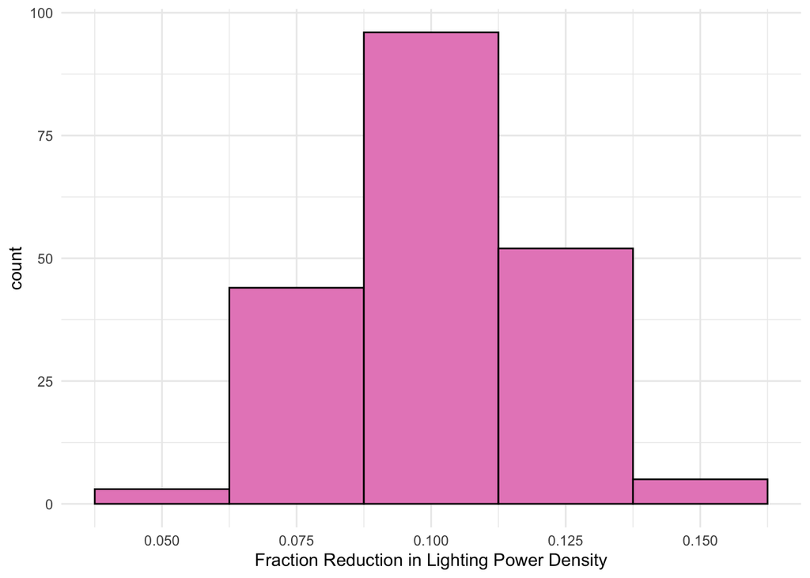

```r
n_samples <- 200

set.seed(1)
r_lpd <- rtri(n = n_samples, min = 0.05, max = 0.15, mode = 0.10)

ggplot(data.frame(x = r_lpd), aes(x)) +
    geom_histogram(binwidth=0.025, colour="black", fill="#E78AC3") +
    labs(x = "Fraction Reduction in Lighting Power Density") +
    scale_x_continuous(breaks=seq(0.025, 0.175, 0.025)) +
    theme_minimal()
```

Code for generating random samples for EPD (`'r_epd`) from triangle distribution and the corresponding histogram.

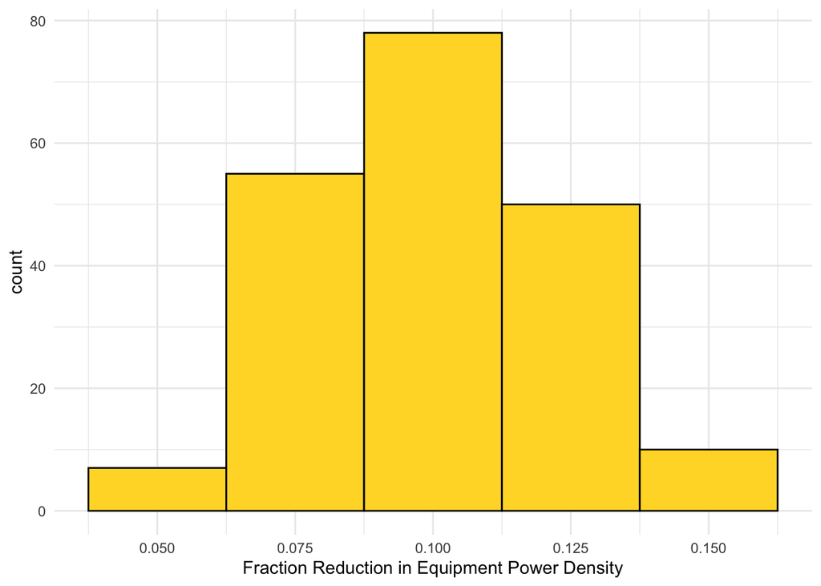

```r
set.seed(2)

r_epd <- rtri(n = n_samples, min = 0.05, max = 0.15, mode = 0.10)

ggplot(data.frame(x = r_epd), aes(x)) +
    geom_histogram(binwidth=0.025, colour="black", fill="#FFD92F") +
    labs(x = "Fraction Reduction in Equipment Power Density") +
    scale_x_continuous(breaks=seq(0.025, 0.175, 0.025)) +
    theme_minimal()
```

## Varying each input independently

In this step, we demonstrate running the energy simulations using the generated samples as inputs to the model. Specifically, we will be analyzing the effects that a reduction in LPD and EPD has on total electricity energy use, independently. Put differently, we will vary only one variable while holding the second one constant (at its original value).

Before we can run the simulations, we need to first define functions that modifies the LPD and EPD in the model. The `ecm` function below modifies the lighting power density and the electric equipment design power by multiplying it by a specified reduction fraction value.

```r
set_frac <- function(idf, class_value, field_value, frac) {
     obj <- idf$to_table() %>%
        filter(class == class_value, field == field_value) %>%
        mutate(value = as.numeric(value) * frac)

    idf$update(obj)

    idf
}

ecm <- function(idf, lpd_frac, epd_frac) {

    idf <- set_frac(idf,
                    "Lights",
                    "Watts per Zone Floor Area",
                    lpd_frac)

    idf <- set_frac(idf,
                    "ElectricEquipment",
                    "Design Level",
                    epd_frac)

    idf
}
```

We first initialize a parametric simulation using `param_job()`. The `$apply_measure()` is used to create the parametric models. In this example, we are creating two sets of parametric simulations. The first with LPD reduced by multiplying it by the reduction fraction value previously generated using the triangle distribution (`r_lpd`) and EPD unchanged. The second with EPD reduced by multiplying it by the reduction fraction value previously generated using the triangle distribution (`r_epd`) and LPD unchanged.

```r
param_model <- param_job(idf_model, epw)

param_model$apply_measure(ecm,
                          lpd_frac = 1-c(r_lpd, rep(0, n_samples)),
                          epd_frac = 1-c(rep(0, n_samples), r_epd),
                          .names = c(paste0("lpd_", 1:n_samples),
                                     paste0("epd_", 1:n_samples)))
```

Here we retrieve the summary of the parameter values and the corresponding model names using `$cases()`.

```r
param_model$cases()
```

```
##      index    case  lpd_frac  epd_frac
##   1:     1   lpd_1 0.9135645 1.0000000
##   2:     2   lpd_2 0.9068651 1.0000000
##   3:     3   lpd_3 0.8962140 1.0000000
##   4:     4   lpd_4 0.8714234 1.0000000
##   5:     5   lpd_5 0.9182445 1.0000000
##  ---
## 396:   396 epd_196 1.0000000 0.9182546
## 397:   397 epd_197 1.0000000 0.9183992
## 398:   398 epd_198 1.0000000 0.9201558
## 399:   399 epd_199 1.0000000 0.9129955
## 400:   400 epd_200 1.0000000 0.9244442
```

The `$run()` method is used to run all parametric simulations in parallel. Each simulation output is placed in its own folder. In this example, we are running a total of 400 simulations (200 simulations for the 200 random variables generated for LPD and 200 simulation for the 200 random variables generated for EPD).

```r
param_model$run()
```

```
## ── EnergPlus Parametric Simulation Job ─────────────────────────────────────────
##  • Path: '/Users/adrianchong/Documents/GitHub/ipmvp-calibration-example/data/mo…
##  • Version: '/Users/adrianchong/Documents/GitHub/ipmvp-calibration-example/data…
##  • EnergyPlus Version: '22.1.0'
##  • EnergyPlus Path: '/Applications/EnergyPlus-22-1-0'
## Applied Measure: 'ecm'
## Parametric Models [400]:
## [001]: 'lpd_1.idf'   <-- SUCCEEDED
## [002]: 'lpd_2.idf'   <-- SUCCEEDED
## [003]: 'lpd_3.idf'   <-- SUCCEEDED
## [004]: 'lpd_4.idf'   <-- SUCCEEDED
## [005]: 'lpd_5.idf'   <-- SUCCEEDED
....
```

The `$tabular_data()` is used to retrieve the EnergyPlus Tabular Output Report from the completed parametric simulations. We then filter the report to contain only the electicity total end use from the End Uses Table in the Annual Building Utility Performance Summary report.

```r
results <- param_model$tabular_data() %>%
    filter(report_name == "AnnualBuildingUtilityPerformanceSummary",
           table_name == "End Uses",
           column_name == "Electricity",
           row_name == "Total End Uses") %>%
    mutate(case = map_chr(str_split(case, "_"), 1),
           value = as.numeric(value), # convert value to numeric
           value = ifelse(units == "GJ", value * 277.778, value),
           units = ifelse(units == "GJ", "kWh", units))
```

Compare the summary statistics of the total electricity end use data retrieved from the parametric simulations.

```r
results_stats <- results %>%
  group_by(case) %>%
  summarize(
    mean = mean(value, na.rm = TRUE),
    sd = sd(value, na.rm = TRUE),
    min = min(value, na.rm = TRUE),
    max = max(value, na.rm = TRUE),
    percentile_25th = quantile(value, 0.25, na.rm = TRUE),
    median = median(value, na.rm = TRUE),
    percentile_75th = quantile(value, 0.75, na.rm = TRUE),
    iqr = IQR(value, na.rm = TRUE)
  )

print(results_stats)
```

```
## # A tibble: 2 × 9
##   case     mean    sd    min    max percentile_25th median percentile_75th   iqr
##   <chr>   <dbl> <dbl>  <dbl>  <dbl>           <dbl>  <dbl>           <dbl> <dbl>
## 1 epd   280902. 4628. 2.72e5 2.90e5         277138. 2.81e5         284717. 7579.
## 2 lpd   296733. 1036. 2.94e5 2.99e5         296017. 2.97e5         297461. 1444.
```

Using the total electricity end use data retrieved from the parametric simulations, we compare them by plotting a histogram of the energy savings.

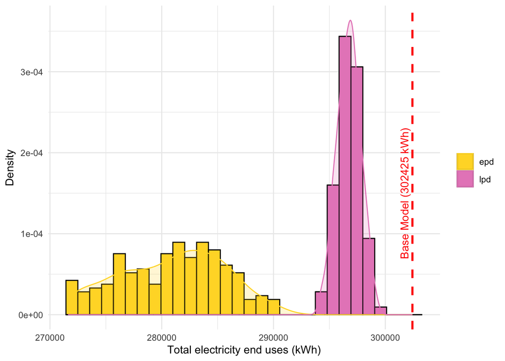

```r
ggplot(results, aes(x = value, fill = case)) +
    geom_histogram(aes(y=..density..), colour = "black") +
    geom_density(aes(color = case), alpha = 0.2) +
    scale_fill_manual(values = c("lpd" = "#E78AC3", "epd" = "#FFD92F")) +
    scale_color_manual(values = c("lpd" = "#E78AC3", "epd" = "#FFD92F")) +
    theme_minimal() +
    labs(x = "Total electricity end uses (kWh)",
         y = "Density") +
    theme(legend.title = element_blank()) +
    geom_vline(xintercept = base_report$value, color = "red", linetype = "dashed", size = 1) +
    annotate("text", x = base_report$value, y = 1.5e-04,
             label = paste("Base Model (", round(base_report$value)," kWh)", sep = ""),
             color = "red", angle = 90, vjust = -0.5)
```

## Varying multiple inputs simultaneously

In the previous example, we simulated the effects of varying LPD and EPD independently. In this example we simulate varying both LPD and EPD simultaneously. We first initialize a new parametric simulation, `param_model_combined`. Since we are varying LPD and EPD simulatneously, we are running less simulations than when varying them independently. We will use the same random variables that we previously generated using the traingular distributions for LPD (`r_lpd`) and EPD (`r_epd`).

```r
param_model_combined <- param_job(idf_model, epw)

param_model_combined$apply_measure(ecm,
                                   lpd_frac = 1-r_lpd,
                                   epd_frac = 1-r_epd,
                                   .names = c(paste0("combined_", 1:n_samples)))
```

Summary of the parameter values using `$cases()` method.

```r
param_model_combined$cases()
```

```
##      index         case  lpd_frac  epd_frac
##   1:     1   combined_1 0.9135645 0.9195959
##   2:     2   combined_2 0.9068651 0.8885763
##   3:     3   combined_3 0.8962140 0.8961884
##   4:     4   combined_4 0.8714234 0.9210128
##   5:     5   combined_5 0.9182445 0.8667572
##  ---
## 196:   196 combined_196 0.8952453 0.9182546
## 197:   197 combined_197 0.9265095 0.9183992
## 198:   198 combined_198 0.8782394 0.9201558
## 199:   199 combined_199 0.9101275 0.9129955
## 200:   200 combined_200 0.8829506 0.9244442
```

Running the parametric simulations using `$run()` method. In this example, we are running a total of 200 simulations (200 simulations for varying EPD and LPD based on 200 random variables generated for each of them simultaneously).

```r
param_model_combined$run()
```

```
## ── EnergPlus Parametric Simulation Job ─────────────────────────────────────────
##  • Path: '/Users/adrianchong/Documents/GitHub/ipmvp-calibration-example/data/mo…
##  • Version: '/Users/adrianchong/Documents/GitHub/ipmvp-calibration-example/data…
##  • EnergyPlus Version: '22.1.0'
##  • EnergyPlus Path: '/Applications/EnergyPlus-22-1-0'
## Applied Measure: 'ecm'
## Parametric Models [200]:
## [001]: 'combined_1.idf'   <-- SUCCEEDED
## [002]: 'combined_2.idf'   <-- SUCCEEDED
## [003]: 'combined_3.idf'   <-- SUCCEEDED
## [004]: 'combined_4.idf'   <-- SUCCEEDED
## [005]: 'combined_5.idf'   <-- SUCCEEDED
....
```

Retrieve the results of the parametric simulation using the `$tabular_data()` method and filtering the data frame to contain only the electricity total end use from the End Uses Table in the Annual Building Utility Performance Summary report.

```r
results_combined <- param_model_combined$tabular_data() %>%
    filter(report_name == "AnnualBuildingUtilityPerformanceSummary",
           table_name == "End Uses",
           column_name == "Electricity",
           row_name == "Total End Uses") %>%
    mutate(value = as.numeric(value), # convert value to numeric
           value = ifelse(units == "GJ", value * 277.778, value),
           units = ifelse(units == "GJ", "kWh", units))
```

Compare the summary statistics of the total electricity end use data retrieved from the parametric simulations.

```r
results_combined_stats <- results_combined %>%
  summarize(
    mean = mean(value, na.rm = TRUE),
    sd = sd(value, na.rm = TRUE),
    min = min(value, na.rm = TRUE),
    max = max(value, na.rm = TRUE),
    percentile_25th = quantile(value, 0.25, na.rm = TRUE),
    median = median(value, na.rm = TRUE),
    percentile_75th = quantile(value, 0.75, na.rm = TRUE),
    iqr = IQR(value, na.rm = TRUE)
  )

print(results_combined_stats)
```

```
##       mean       sd      min      max percentile_25th   median percentile_75th
## 1 275204.5 4619.575 265280.8 285666.9        271446.7 275950.2        278677.3
##        iqr
## 1 7230.561
```

Visualize the energy savings from simulating changes in both LPD and EPD simulatenously.

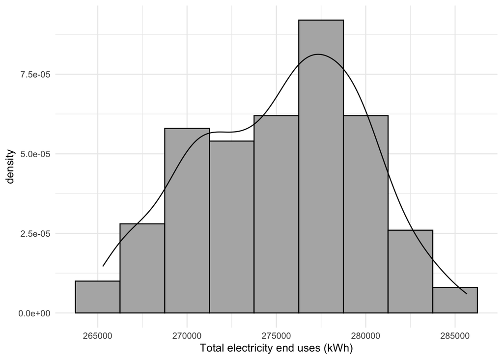

```r
ggplot(results_combined, aes(x = value)) +
    geom_histogram(aes(y=..density..), binwidth = 2500, fill = "#B3B3B3", colour = "black") +
    geom_density(alpha = 0.2) +
    labs(x = "Total electricity end uses (kWh)") +
    theme_minimal()
```